# Housing Prices Prediciton

# 1. Loading libraries and data

```r
library(knitr)
library(ggplot2)
library(plyr)
library(dplyr)
library(corrplot)
library(caret)
library(gridExtra)
library(scales)
library(Rmisc)
library(ggrepel)
library(randomForest)
library(psych)
library(xgboost)
```

```r
train <- read.csv("train.csv", stringsAsFactors = F)
test <- read.csv("test.csv", stringsAsFactors = F)
```

We edit the Id and SalePrice columns for the purpose of prediction and submission. We merge for the sake of exploration and data wrangling.

```r
test_id <- test$Id
test$Id <- NULL
train$Id <- NULL

test$SalePrice <- NA
all <- rbind(train, test)
all$index <- 1:nrow(all)
```

# 2. Data Exploration

First we graph a histogram of the data.

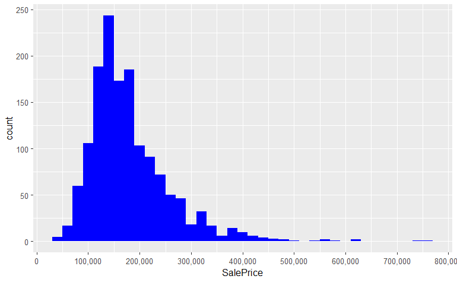

```r
ggplot(data = all[!is.na(all$SalePrice),], aes(x = SalePrice)) +
  geom_histogram(binwidth = 20000, fill = 'blue') +
  scale_x_continuous(breaks = seq(0, 800000, by = 100000), labels = comma)
```

```r
summary(all$SalePrice)
```

```
   Min. 1st Qu.  Median    Mean 3rd Qu.    Max.    NA's
  34900  129975  163000  180921  214000  755000    1459
```

### 2.1 High Correlations Numerical Columns

```r
numericCols <- which(sapply(all, is.numeric))
numericColsNames <- names(numericCols)
cat('There are', length(numericColsNames), 'numeric columns')
```

```
There are 38 numeric columns
```

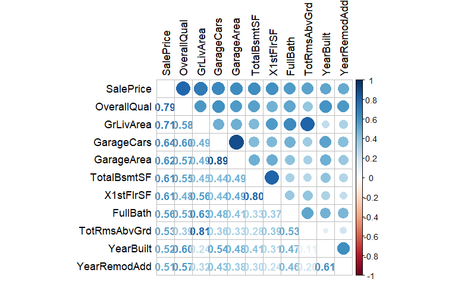

```r
all_num <- all[, numericColsNames]

#correlations
cor_num <- cor(all_num, use = "pairwise.complete.obs")

#sorting
cor_num_sorted <- as.matrix(sort(cor_num[, 'SalePrice'], decreasing = TRUE))

cor_num_top <- names(which(apply(cor_num_sorted, 1, function(x) abs(x) > 0.5)))

cor_num <- cor_num[cor_num_top, cor_num_top]

corrplot.mixed(cor_num, tl.col = 'black', tl.pos = 'lt')
```

We see that OverallQual is the most meaningful feature. We further analyse it.

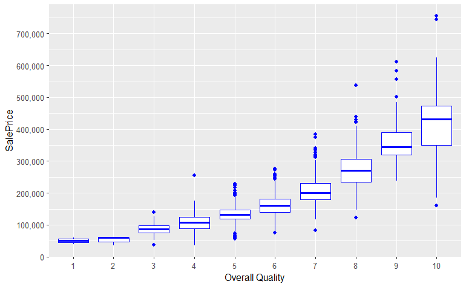

```r
ggplot(data = all[!is.na(all$SalePrice),], aes(x=factor(OverallQual), y = SalePrice)) +
  geom_boxplot(col = 'blue') +
  labs(x = 'Overall Quality') +
  scale_y_continuous(breaks = seq(0,800000, by = 100000), labels = comma)
```

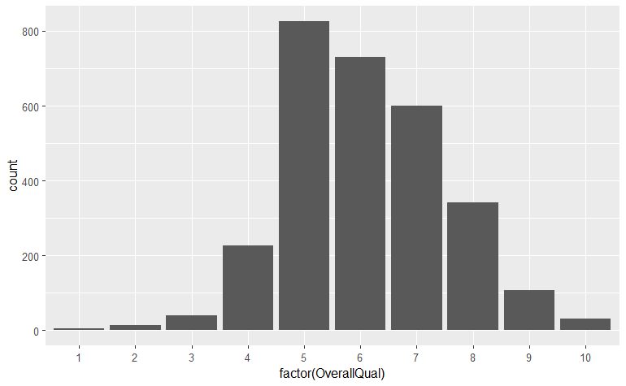

```r
ggplot(data = all[!is.na(all$OverallQual),], aes(x = factor(OverallQual)))+
  geom_bar(stat='count')
```

Now we analysie GrLivArea.

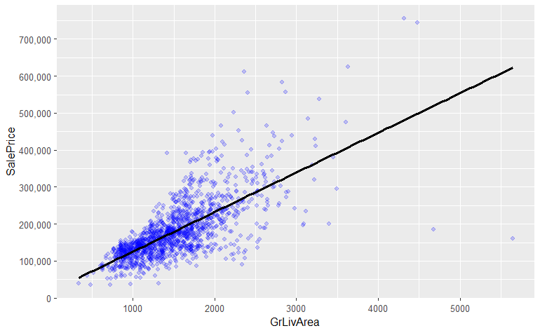

```r
ggplot(data = all[!is.na(all$SalePrice),], aes(x=GrLivArea, y = SalePrice))+
  geom_point(col = 'blue', alpha = 0.2)+
  geom_smooth(method = 'lm', se = FALSE, color = 'black', aes(group = 1))+
  scale_y_continuous(breaks = seq(00,800000, by = 100000), labels = comma)+
  geom_text_repel(aes(label = ifelse(all$GrLivArea[!is.na(all$SalePrice)]>4500, rownames(all), ' ')))
```

# 3. Missing Data

```r
NACols <- which(colSums(is.na(all))>0)
sort(colSums(is.na(all[NACols])), decreasing = TRUE)
```

```
      PoolQC  MiscFeature        Alley        Fence    SalePrice  FireplaceQu  LotFrontage  GarageYrBlt
        2909         2814         2721         2348         1459         1420          486          159
GarageFinish   GarageQual   GarageCond   GarageType     BsmtCond BsmtExposure     BsmtQual BsmtFinType2
         159          159          159          157           82           82           81           80
BsmtFinType1   MasVnrType   MasVnrArea     MSZoning    Utilities BsmtFullBath BsmtHalfBath   Functional
          79           24           23            4            2            2            2            2
 Exterior1st  Exterior2nd   BsmtFinSF1   BsmtFinSF2    BsmtUnfSF  TotalBsmtSF   Electrical  KitchenQual
           1            1            1            1            1            1            1            1
  GarageCars   GarageArea     SaleType
           1            1            1
```

## Pool Variable

```r
all$PoolQC[is.na(all$PoolQC)] <- 'None'

Qualities <- c('None' = 0, 'Po' = 1, 'Fa' = 2, 'TA' = 3, 'Gd' = 4, 'Ex' = 5)
all$PoolQC <- as.integer(revalue(all$PoolQC, Qualities))
table(all$PoolQC)
```

```
   0    2    4    5
2909    2    4    4
```

We find a few cases where the quality of the pools is NA but the pools exist - have a positive PoolArea. We hence impute the Quality according to the overall quality of the house.

```r
all[all$PoolArea>0 & all$PoolQC==0, c('PoolArea', 'PoolQC', 'OverallQual')]
```

|  | PoolArea | PoolQC | OverallQual |
| --- | --- | --- | --- |
| 2421 | 368 | 0 | 4 |
| 2504 | 444 | 0 | 6 |
| 2600 | 561 | 0 | 3 |

```r
all$PoolQC[2421] <- 2
all$PoolQC[2504] <- 3
all$PoolQC[2600] <- 2
```

## Misc Variable

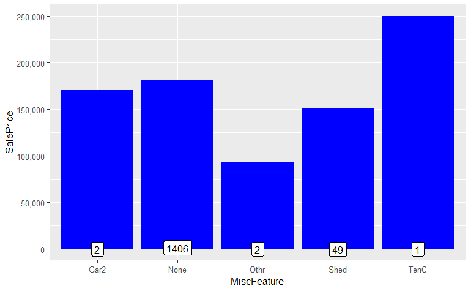

```r
all$MiscFeature[which(is.na(all$MiscFeature))] <- 'None'
all$MiscFeature <- as.factor(all$MiscFeature)

ggplot(data = all[!is.na(all$SalePrice),], aes(x = MiscFeature, y = SalePrice)) +
  geom_bar(stat = 'summary', fun = 'mean', fill = 'blue') +
  scale_y_continuous(breaks = seq(0, 300000, by = 50000), labels = comma)+
  geom_label(stat = 'count', aes(label = ..count.., y = ..count..))
```

## Alley

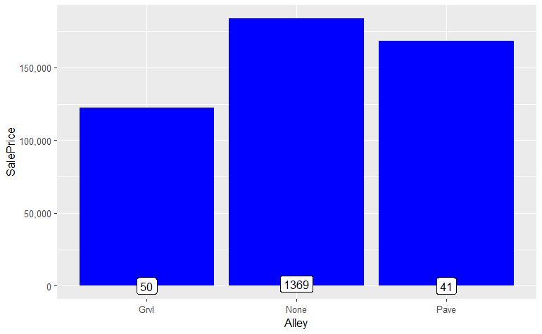

```r
all$Alley[is.na(all$Alley)] <- 'None'
all$Alley <- as.factor(all$Alley)

ggplot(data = all[!is.na(all$SalePrice),], aes(x=Alley, y = SalePrice))+
  geom_bar(stat = 'summary',fun = 'mean', fill='blue')+
  scale_y_continuous(breaks = seq(0,250000, by=50000), labels = comma)+
  geom_label(stat = 'count', aes(label = ..count.., y = ..count..))
```

## Fence

```r
all$Fence[is.na(all$Fence)] <- 'None'
all[!is.na(all$SalePrice),] %>%
  group_by(Fence) %>%
  summarise(mean = mean(SalePrice), count = n())
```

| Fence | mean | count |
| --- | --- | --- |
| GdPrv | 178927.5 | 59 |
| GdWo | 140379.3 | 54 |
| MnPrv | 148751.1 | 157 |
| MnWw | 134286.4 | 11 |
| None | 187596.8 | 1179 |

The values don’t seem ordinal so we convert them to a factor.

```r
all$Fence <- as.factor(all$Fence)
```

## Fireplace

```r
all$FireplaceQu[is.na(all$FireplaceQu)] <- 'None'
all$FireplaceQu <- as.integer(revalue(all$FireplaceQu, Qualities))
table(all$FireplaceQu)
```

```
   0    1    2    3    4    5
1420   46   74  592  744   43
```

```r
sum(is.na(all$Fireplaces))
```

```
[1] 0
```

## LotFrontage

```r
all <- all %>%
  group_by(Neighborhood) %>%
  mutate(LotFrontage = ifelse(is.na(LotFrontage), mean(LotFrontage, na.rm=TRUE), LotFrontage))

sum(is.na(all$LotFrontage))
```

```
[1] 0
```

## LotShape

```r
sum(is.na(all$LotShape))
```

```
[1] 0
```

```r
table(all$LotShape)
```

```
 IR1  IR2  IR3  Reg
 968   76   16 1859
```

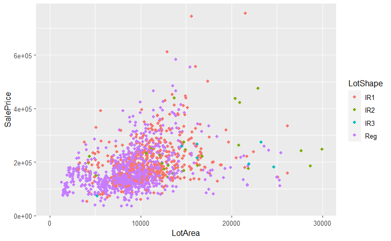

```r
ggplot(data = all[!is.na(all$SalePrice),], aes(x = LotArea, y = SalePrice, color = LotShape))+
  geom_point()+
  scale_x_continuous(limits=c(0,30000))
```

```r
NA
NA
NA
```

```r
for (shape in unique(all$LotShape)){
  a <- all[!is.na(all$SalePrice),c('LotShape','SalePrice')]
  a <- a %>%
    mutate(LotShape=ifelse(LotShape==shape,1, 0))
cat(shape, 'correlation to price: ', cor(a$LotShape, a$SalePrice, method = c("pearson", "kendall", "spearman")), '\n')
}
```

```
Reg correlation to price:  -0.2676718
IR1 correlation to price:  0.2232839
IR2 correlation to price:  0.1260961
IR3 correlation to price:  0.03672048
```

```r
Qualities1 <- c('Reg'=0, 'IR3'=1, 'IR2'=2, 'IR1'=3)
Qualities2 <- c('Reg'=3, 'IR3'=0, 'IR2'=1, 'IR1'=2)

a <- all[!is.na(all$SalePrice),c('LotShape','SalePrice')]
a$LotShape <- as.integer(revalue(a$LotShape, Qualities1))
cat('Computed optimal encoding:',cor(a$LotShape, a$SalePrice, method = c("pearson", "kendall", "spearman")), '\n')
```

```
Computed optimal encoding: 0.2555799
```

```r
a <- all[!is.na(all$SalePrice),c('LotShape','SalePrice')]
a$LotShape <- as.integer(revalue(a$LotShape, Qualities2))
cat('Intuitive optimal encoding: ',cor(a$LotShape, a$SalePrice, method = c("pearson", "kendall", "spearman")))
```

```
Intuitive optimal encoding:  -0.2677593
```

We will hence use the intuitive encoding.

```r
all$LotShape <- as.integer(revalue(all$LotShape, Qualities2))
```

## Garage

```r
GarageCols <- grep('Garage', colnames(all), value=TRUE)

colSums(is.na(all[GarageCols]))
```

```
  GarageType  GarageYrBlt GarageFinish   GarageCars   GarageArea   GarageQual   GarageCond
         157          159          159            1            1          159          159
```

Year built - replace with house build year

```r
all$GarageYrBlt[is.na(all$GarageYrBlt)] <- all$YearBuilt[is.na(all$GarageYrBlt)]
```

We see that the NAs are from the same observations.

```r
length(which(is.na(all$GarageType) & is.na(all$GarageFinish) & is.na(all$GarageQual)& is.na(all$GarageCond)))
```

```
[1] 157
```

```r
all[!is.na(all$GarageType) & is.na(all$GarageFinish), c('index',GarageCols)]
```

| index | GarageType | GarageYrBlt | GarageFinish | GarageCars | GarageArea | GarageQual | GarageCond |
| --- | --- | --- | --- | --- | --- | --- | --- |
| 2127 | Detchd | 1910 | NA | 1 | 360 | NA | NA |
| 2577 | Detchd | 1923 | NA | NA | NA | NA | NA |

One of them seems to be an existing garage without the values, the other 158 including. For the observation 2127 we impute the modes.

```r
all$GarageCond[2127] <- names(sort(-table(all$GarageCond)))[1]
all$GarageQual[2127] <- names(sort(-table(all$GarageQual)))[1]
all$GarageFinish[2127] <- names(sort(-table(all$GarageFinish)))[1]
```

For the case of observation 2577 we assume there is no garage.

```r
all$GarageCars[2577] <- 0
all$GarageArea[2577] <- 0
all$GarageType[2577] <- NA
colSums(is.na(all[GarageCols]))
```

```
  GarageType  GarageYrBlt GarageFinish   GarageCars   GarageArea   GarageQual   GarageCond
         158            0          158            0            0          158          158
```

```r
length(which(is.na(all$GarageType) & is.na(all$GarageFinish) & is.na(all$GarageQual)& is.na(all$GarageCond)))
```

```
[1] 158
```

So we have the remaining 158 observations without a garage. We take care of the features now. GarageType

```r
all$GarageType[is.na(all$GarageType)] <- 'No Garage'
all$GarageType <- as.factor(all$GarageType)
table(all$GarageType)
```

```
   2Types    Attchd   Basment   BuiltIn   CarPort    Detchd No Garage
       23      1723        36       186        15       778       158
```

GarageFinish - it is ordinal

```r
all$GarageFinish[is.na(all$GarageFinish)] <- 'None'
Finish <- c('None'=0,'Unf'=1,'RFn'=2,'Fin'=3)

all$GarageFinish <- as.integer(revalue(all$GarageFinish,Finish))
table(all$GarageFinish)
```

```
   0    1    2    3
 158 1231  811  719
```

GarageQual - ordinal

```r
all$GarageQual[is.na(all$GarageQual)] <- 'None'
all$GarageQual <- as.integer(revalue(all$GarageQual, Qualities))
table(all$GarageQual)
```

```
   0    1    2    3    4    5
 158    5  124 2605   24    3
```

GarageCond - ordinal

```r
all$GarageCond[is.na(all$GarageCond)] <- 'None'
all$GarageCond <- as.integer(revalue(all$GarageCond, Qualities))
table(all$GarageCond)
```

```
   0    1    2    3    4    5
 158   14   74 2655   15    3
```

## Basement

```r
BsmtCols <- grep('Bsmt', colnames(all), value=TRUE)
colSums(is.na(all[BsmtCols]))
```

```
    BsmtQual     BsmtCond BsmtExposure BsmtFinType1   BsmtFinSF1 BsmtFinType2   BsmtFinSF2    BsmtUnfSF
          81           82           82           79            1           80            1            1
 TotalBsmtSF BsmtFullBath BsmtHalfBath
           1            2            2
```

```r
BsmtGroup1 <- names(which(colSums(is.na(all[BsmtCols]))>70))

length(which(is.na(all$BsmtQual) & is.na(all$BsmtCond) & is.na(all$BsmtExposure) & is.na(all$BsmtFinType1) & is.na(all$BsmtFinType2)))
```

```
[1] 79
```

```r
all[!is.na(all$BsmtFinType1) & (is.na(all$BsmtCond)|is.na(all$BsmtQual)|is.na(all$BsmtExposure)|is.na(all$BsmtFinType2)), c('index','BsmtQual', 'BsmtCond', 'BsmtExposure', 'BsmtFinType1', 'BsmtFinType2')]
```

| index | BsmtQual | BsmtCond | BsmtExposure | BsmtFinType1 | BsmtFinType2 |
| --- | --- | --- | --- | --- | --- |
| 333 | Gd | TA | No | GLQ | NA |
| 949 | Gd | TA | NA | Unf | Unf |
| 1488 | Gd | TA | NA | Unf | Unf |
| 2041 | Gd | NA | Mn | GLQ | Rec |
| 2186 | TA | NA | No | BLQ | Unf |
| 2218 | NA | Fa | No | Unf | Unf |
| 2219 | NA | TA | No | Unf | Unf |
| 2349 | Gd | TA | NA | Unf | Unf |
| 2525 | TA | NA | Av | ALQ | Unf |

From this we see that there are 79 houses without basements and 9 have missing values.

```r
all$BsmtFinType2[333] <- names(sort(-table(all$BsmtFinType2)))[1]
all$BsmtExposure[c(949,1488,2349)]<- names(sort(-table(all$BsmtExposure)))[1]
all$BsmtCond[c(2041, 2186, 2525)] <- names(sort(-table(all$BsmtCond)))[1]
all$BsmtQual[c(2218, 2219)] <- names(sort(-table(all$BsmtQual)))[1]
```

```r
all$BsmtQual[is.na(all$BsmtQual)] <- 'None'
all$BsmtQual<-as.integer(revalue(all$BsmtQual, Qualities))
all$BsmtCond[is.na(all$BsmtCond)] <- 'None'
all$BsmtCond<-as.integer(revalue(all$BsmtCond, Qualities))
all$BsmtExposure[is.na(all$BsmtExposure)] <- 'None'
Exposure <- c('None'=0, 'No'=1, 'Mn'=2, 'Av'=3, 'Gd'=4)
all$BsmtExposure<-as.integer(revalue(all$BsmtExposure, Exposure))

FinType <- c('None'=0, 'Unf'=1, 'LwQ'=2, 'Rec'=3, 'BLQ'=4, 'ALQ'=5, 'GLQ'=6)
all$BsmtFinType1[is.na(all$BsmtFinType1)] <- 'None'
all$BsmtFinType1<-as.integer(revalue(all$BsmtFinType1, FinType))
all$BsmtFinType2[is.na(all$BsmtFinType2)] <- 'None'
all$BsmtFinType2<-as.integer(revalue(all$BsmtFinType2, FinType))
```

```r
a <- all[BsmtCols][which(colSums(is.na(all[BsmtCols]))>0)] #Get columns from BsmtCols which have a NA value

a[which(rowSums(is.na(a))>0),]
```

| BsmtFinSF1 | BsmtFinSF2 | BsmtUnfSF | TotalBsmtSF | BsmtFullBath | BsmtHalfBath |
| --- | --- | --- | --- | --- | --- |
| NA | NA | NA | NA | NA | NA |
| 0 | 0 | 0 | 0 | NA | NA |

```r
all$BsmtFullBath[is.na(all$BsmtFullBath)] <-0
all$BsmtHalfBath[is.na(all$BsmtHalfBath)] <-0
all$BsmtFinSF1[is.na(all$BsmtFinSF1)] <-0
all$BsmtFinSF2[is.na(all$BsmtFinSF2)] <-0
all$BsmtUnfSF[is.na(all$BsmtUnfSF)] <-0
all$TotalBsmtSF[is.na(all$TotalBsmtSF)] <-0
colSums(is.na(all[BsmtCols]))
```

```
    BsmtQual     BsmtCond BsmtExposure BsmtFinType1   BsmtFinSF1 BsmtFinType2   BsmtFinSF2    BsmtUnfSF
           0            0            0            0            0            0            0            0
 TotalBsmtSF BsmtFullBath BsmtHalfBath
           0            0            0
```

## Masonry

```r
MasCols <- grep('Mas', colnames(all), value=TRUE)
```

```r
colSums(is.na(all[,MasCols]))
```

```
MasVnrType MasVnrArea
        24         23
```

```r
length(which(is.na(all$MasVnrArea) & is.na(all$MasVnrType)))
```

```
[1] 23
```

```r
all[is.na(all$MasVnrType) & !is.na(all$MasVnrArea), c('index','MasVnrType', 'MasVnrArea')]
```

| index | MasVnrType | MasVnrArea |
| --- | --- | --- |
| 2611 | NA | 198 |

```r
all$MasVnrType[2611] <- names(sort(-table(all$MasVnrType)))[2] # number 1 is None
all$MasVnrType[is.na(all$MasVnrType)] <- 'None'

all[!is.na(all$SalePrice),] %>%
  group_by(MasVnrType) %>%
  summarise(MeanPrice = mean(SalePrice), count = n()) %>%
  arrange(MeanPrice)
```

| MasVnrType | MeanPrice | count |
| --- | --- | --- |
| BrkCmn | 146318.1 | 15 |
| None | 156958.2 | 872 |
| BrkFace | 204691.9 | 445 |
| Stone | 265583.6 | 128 |

```r
Masonry <- c('None'=0, 'BrkCmn'=0, 'BrkFace'=1, 'Stone'=2)
all$MasVnrType<-as.integer(revalue(all$MasVnrType, Masonry))

all$MasVnrArea[is.na(all$MasVnrArea)] <- 0
```

## MSZoning

```r
table(all$Neighborhood)
```

```
Blmngtn Blueste  BrDale BrkSide ClearCr CollgCr Crawfor Edwards Gilbert  IDOTRR MeadowV Mitchel   NAmes
     28      10      30     108      44     267     103     194     165      93      37     114     443
NoRidge NPkVill NridgHt  NWAmes OldTown  Sawyer SawyerW Somerst StoneBr   SWISU  Timber Veenker
     71      23     166     131     239     151     125     182      51      48      72      24
```

We want to know whether or not the MSZoning variable is similar within one Neighborhood. By the below calculations we see that they indeed are. Most ratios are above 0.9, with a few exceptions. Hence we can impute missing tables according to the most common MSZoning within the Neighborhood of the observation.

```r
all %>%
  count(Neighborhood, MSZoning, sort=TRUE) %>%
  group_by(Neighborhood) %>%
  summarise(most_frequent_zoning_count = n[1], neighborhood_size = sum(n), max_ratio = most_frequent_zoning_count/neighborhood_size) %>%
  select(Neighborhood, 'max_ratio')
```

| Neighborhood | max_ratio |
| --- | --- |
| Blmngtn | 0.8928571 |
| Blueste | 1.0000000 |
| BrDale | 1.0000000 |
| BrkSide | 0.6018519 |
| ClearCr | 1.0000000 |
| CollgCr | 0.9475655 |
| Crawfor | 0.8834951 |
| Edwards | 0.9278351 |
| Gilbert | 1.0000000 |
| IDOTRR | 0.7311828 |

[output cut: 15 more lines]

```r
NA
```

```r
most_freq_zoning <- all %>%
  group_by(Neighborhood) %>%
  summarise(zone = names(which.max(table(MSZoning))))

all$MSZoning <- ifelse(is.na(all$MSZoning), most_freq_zoning$zone[match(all$Neighborhood, most_freq_zoning$Neighborhood)], all$MSZoning)
```

## Kitchen

```r
colSums(is.na(all[,c('KitchenAbvGr','KitchenQual')]))
```

```
KitchenAbvGr  KitchenQual
           0            1
```

```r
all[is.na(all$KitchenQual), c('KitchenAbvGr', 'SalePrice','OverallQual')]
```

| KitchenAbvGr | SalePrice | OverallQual |
| --- | --- | --- |
| 1 | NA | 5 |

```r
all$KitchenQual[is.na(all$KitchenQual)] <- 'TA'
all$KitchenQual <- as.integer(revalue(all$KitchenQual, Qualities))
```

## Utilities

```r
sum(is.na(all$Utilities))
```

```
[1] 2
```

```r
table(all$Utilities)
```

```
AllPub NoSeWa
  2916      1
```

```r
all$Utilities <- NULL
```

## Functional

```r
all$Functional[is.na(all$Functional)] <- names(sort(-table(all$Functional)))[1]

all$Functional <- as.integer(revalue(all$Functional, c('Sal'=0, 'Sev'=1, 'Maj2'=2, 'Maj1'=3, 'Mod'=4, 'Min2'=5, 'Min1'=6, 'Typ'=7)))
sum(is.na(all$Functional))
```

```
[1] 0
```

## Exterior

```r
all[which(is.na(all$Exterior1st)), c('Exterior1st', 'Exterior2nd')]
```

| Exterior1st | Exterior2nd |
| --- | --- |
| NA | NA |

```r
all$Exterior1st[is.na(all$Exterior1st)] <- names(sort(-table(all$Exterior1st)))[1]
all$Exterior1st <- as.factor(all$Exterior1st)
all$Exterior2nd[is.na(all$Exterior2nd)] <- names(sort(-table(all$Exterior2nd)))[1]
all$Exterior2nd <- as.factor(all$Exterior2nd)
```

The two missing values are both in one observation.

```r
all$ExterQual<-as.integer(revalue(all$ExterQual, Qualities))
all$ExterCond<-as.integer(revalue(all$ExterCond, Qualities))
```

## Electrical

Imputing mode

```r
all$Electrical[is.na(all$Electrical)] <- names(sort(-table(all$Electrical)))[1]
all$Electrical <- as.factor(all$Electrical)
```

## SaleType

Imputing Mode

```r
all$SaleType[is.na(all$SaleType)] <- names(sort(-table(all$SaleType)))[1]
all$SaleType <- as.factor(all$SaleType)
```

## Sale Condition

```r
all$SaleCondition <- as.factor(all$SaleCondition)
```

# 4. Label Encoding

```r
charCol <- names(all[,sapply(all,is.character)])
length(charCol)
```

```
[1] 17
```

```r
all$Foundation <- as.factor(all$Foundation)
all$Heating <- as.factor(all$Heating)
all$HeatingQC<-as.integer(revalue(all$HeatingQC, Qualities))
all$CentralAir<-as.integer(revalue(all$CentralAir, c('N'=0, 'Y'=1)))
all$RoofStyle <- as.factor(all$RoofStyle)
all$RoofMatl <- as.factor(all$RoofMatl)
all$LandContour <- as.factor(all$LandContour)
all$LandSlope<-as.integer(revalue(all$LandSlope, c('Sev'=0, 'Mod'=1, 'Gtl'=2)))
all$BldgType <- as.factor(all$BldgType)
all$HouseStyle <- as.factor(all$HouseStyle)
all$Neighborhood <- as.factor(all$Neighborhood)
all$Condition1 <- as.factor(all$Condition1)
all$Condition2 <- as.factor(all$Condition2)
all$Street<-as.integer(revalue(all$Street, c('Grvl'=0, 'Pave'=1)))
all$PavedDrive<-as.integer(revalue(all$PavedDrive, c('N'=0, 'P'=1, 'Y'=2)))
all$MoSold <- as.factor(all$MoSold)
```

Neighborhood avg price

```r
all <- all%>%
  group_by(Neighborhood) %>%
  mutate(NeighborhoodAvgPrice = mean(SalePrice, na.rm=TRUE))
```

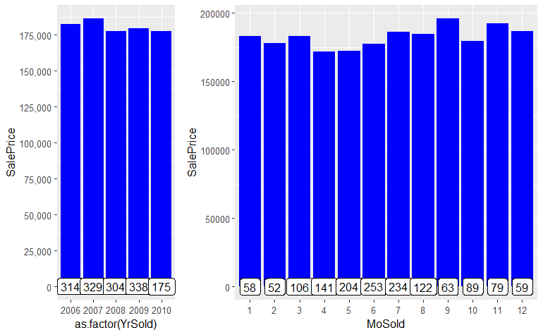

```r
ys <- ggplot(all[!is.na(all$SalePrice),], aes(x=as.factor(YrSold), y=SalePrice)) +
        geom_bar(stat='summary', fun = "mean", fill='blue')+
        scale_y_continuous(breaks= seq(0, 800000, by=25000), labels = comma) +
        geom_label(stat = "count", aes(label = ..count.., y = ..count..))
ms <- ggplot(all[!is.na(all$SalePrice),], aes(x=MoSold, y=SalePrice))+
  geom_bar(stat='summary', fun='mean',fill='blue')+
  geom_label(stat = "count", aes(label = ..count.., y = ..count..))

grid.arrange(ys, ms, widths=c(1,2))
```

```r
all$MSSubClass <- as.factor(all$MSSubClass)
all$MSSubClass<-revalue(all$MSSubClass, c('20'='1 story 1946+', '30'='1 story 1945-', '40'='1 story unf attic', '45'='1,5 story unf', '50'='1,5 story fin', '60'='2 story 1946+', '70'='2 story 1945-', '75'='2,5 story all ages', '80'='split/multi level', '85'='split foyer', '90'='duplex all style/age', '120'='1 story PUD 1946+', '150'='1,5 story PUD all', '160'='2 story PUD 1946+', '180'='PUD multilevel', '190'='2 family conversion'))
```

```r
all$index <- NULL

numericVars <- which(sapply(all, is.numeric)) #index vector numeric variables
factorVars <- which(sapply(all, is.factor)) #index vector factor variables
cat('There are', length(numericVars), 'numeric variables, and', length(factorVars), 'categoric variables')
```

```
There are 57 numeric variables, and 21 categoric variables
```

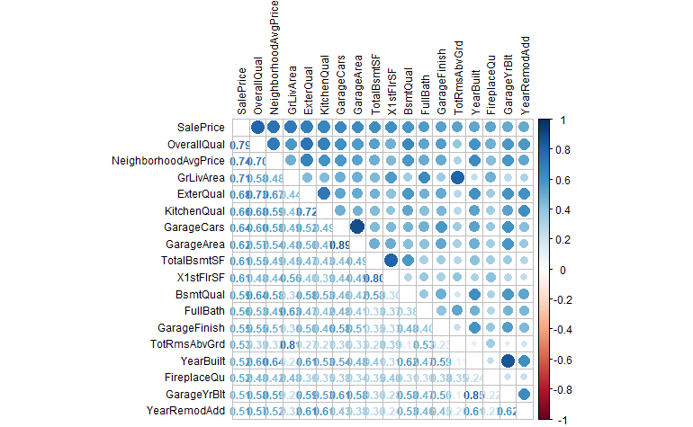

```r
all_numVar <- all[, numericVars]
cor_numVar <- cor(all_numVar, use="pairwise.complete.obs")

cor_sorted <- as.matrix(sort(cor_numVar[,'SalePrice'], decreasing = TRUE))
CorHigh <- names(which(apply(cor_sorted, 1, function(x) abs(x)>0.5)))
cor_numVar <- cor_numVar[CorHigh, CorHigh]

corrplot.mixed(cor_numVar, tl.col="black", tl.pos = "lt", tl.cex = 0.7,cl.cex = .7, number.cex=.7)
```

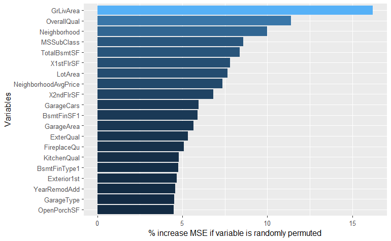

```r
quick_RF <- randomForest(x=all[1:1460,-79], y=all$SalePrice[1:1460], ntree=100,importance=TRUE)
imp_RF <- importance(quick_RF)
imp_DF <- data.frame(Variables = row.names(imp_RF), MSE = imp_RF[,1])
imp_DF <- imp_DF[order(imp_DF$MSE, decreasing = TRUE),]

ggplot(imp_DF[1:20,], aes(x=reorder(Variables, MSE), y=MSE, fill=MSE)) + geom_bar(stat = 'identity') + labs(x = 'Variables', y= '% increase MSE if variable is randomly permuted') + coord_flip() + theme(legend.position="none")
```

```r
all$TotBathrooms <- all$FullBath + (all$HalfBath*0.5) + all$BsmtFullBath + (all$BsmtHalfBath*0.5)
```

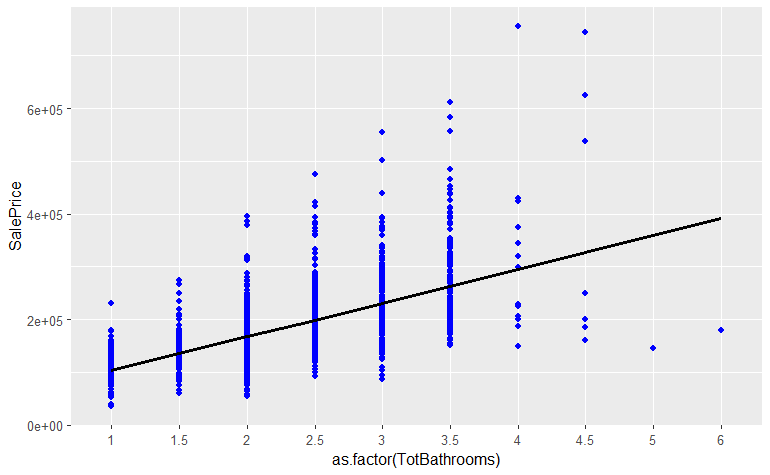

```r
ggplot(data=all[!is.na(all$SalePrice),],aes(x=as.factor(TotBathrooms), y= SalePrice))+
  geom_point(col='blue')+
  geom_smooth(method='lm', se=FALSE,color='black', aes(group=1))
```

```r
all$Remod <- ifelse(all$YearBuilt==all$YearRemodAdd, 0, 1)
all$Age <- as.numeric(all$YrSold)-all$YearRemodAdd
```

```r
all$IsNew <- ifelse(all$YrSold<=all$YearBuilt+3, 1, 0)
table(all$IsNew)
```

```
   0    1
2434  485
```

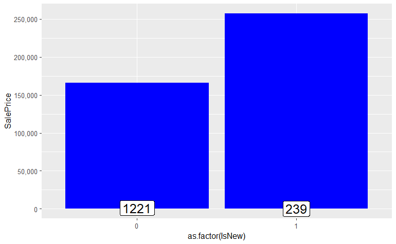

```r
ggplot(all[!is.na(all$SalePrice),], aes(x=as.factor(IsNew), y=SalePrice)) +
        geom_bar(stat='summary', fun = "mean", fill='blue') +
        geom_label(stat = "count", aes(label = ..count.., y = ..count..), size=6) +
        scale_y_continuous(breaks= seq(0, 800000, by=50000), labels = comma)
```

```r
all$YrSold <- as.factor(all$YrSold)
```

```r
b <- all[!is.na(all$SalePrice),c('Neighborhood','SalePrice')] %>%
  group_by(Neighborhood) %>%
  summarise(Mean=mean(SalePrice),Count=n()) %>%
  arrange(Mean)
```

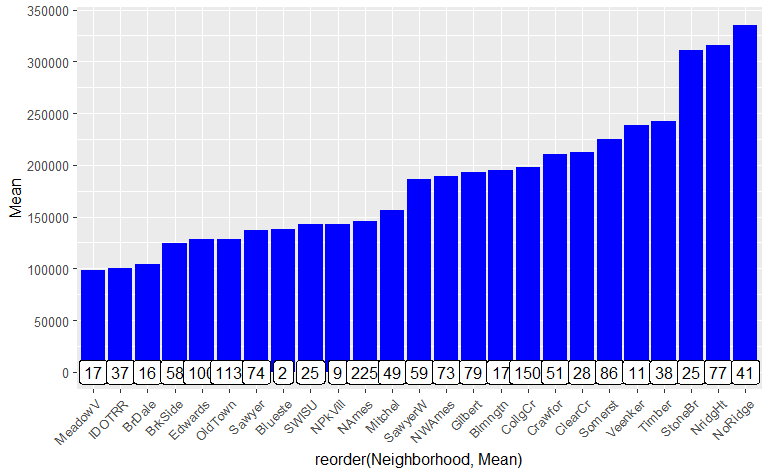

```r
ggplot(data = b, aes(x=reorder(Neighborhood,Mean), y=Mean))+
  geom_bar(stat='summary',fill='blue')+
  theme(axis.text.x = element_text(angle = 45, hjust = 1)) +
  geom_label(stat="count", aes(label = Count, y = ..count..))+
  scale_y_continuous(breaks=seq(0,800000,by=50000))
```

```r
lev0 <- pull(b[b$Mean<126000,'Neighborhood'],Neighborhood)
lev1 <- pull(b[b$Mean>=126000 & b$Mean<175000, 'Neighborhood'],Neighborhood)
lev2 <- pull(b[b$Mean>=175000 & b$Mean<250000, 'Neighborhood'],Neighborhood)
lev3 <- pull(b[b$Mean>250000,'Neighborhood'],Neighborhood)

all$NeighRich <- 0
all$NeighRich[all$Neighborhood %in% lev0] <- 0
all$NeighRich[all$Neighborhood %in% lev1] <- 1
all$NeighRich[all$Neighborhood %in% lev2] <- 2
all$NeighRich[all$Neighborhood %in% lev3] <- 3
```

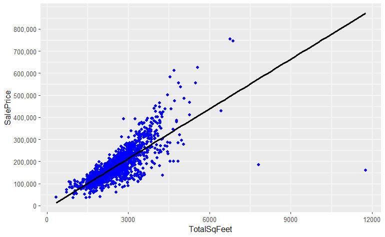

```r
all$TotalSqFeet <- all$GrLivArea + all$TotalBsmtSF

ggplot(all[!is.na(all$SalePrice),], aes(x=TotalSqFeet, y=SalePrice))+
  geom_point(col='blue')+
  scale_y_continuous(breaks= seq(0, 800000, by=100000), labels = comma) +
  geom_smooth(method='lm', se=FALSE,color='black', aes(group=1))
```

```r
all$TotalPorchSF <- all$OpenPorchSF + all$EnclosedPorch + all$X3SsnPorch + all$ScreenPorch
```

```r
numericCols <- which(sapply(all, is.numeric))
numericColsNames <- names(numericCols)
cat('There are', length(numericColsNames), 'numeric columns')
```

```
There are 63 numeric columns
```

```r
all_num <- all[, numericColsNames]

cor_num <- cor(all_num, use = "pairwise.complete.obs")
```

```r
w <- which(abs(cor_num)>0.8 & row(cor_num)<col(cor_num),arr.ind=TRUE)

high_cor <- matrix(c(colnames(cor_num)[w],abs(cor_num[w])),ncol=3)
high_cor1 <- matrix(colnames(cor_num)[w],ncol=1)
#high_cor <- high_cor[order(high_cor[,3],decreasing = TRUE),]
high_cor <- data.frame(high_cor)
colnames(high_cor) <- c('Feat1','Feat2','Corr')

corrs <- data.frame(matrix(abs(cor(all[,c(high_cor1)],all$SalePrice,use = "complete.obs")),ncol=2))
colnames(corrs) <- c('Feat1_Corr_With_SalePrice','Feat2_Corr_With_SalePrice')

#we add correlations with SalePrice, so we can remove the ones with the lower number.
high_cor <- bind_cols(high_cor,corrs)
high_cor <- high_cor[order(high_cor[,3],decreasing = TRUE),]
high_cor
```

|  | Feat1 | Feat2 | Corr | Feat1_Corr_With_SalePrice | Feat2_Corr_With_SalePrice |
| --- | --- | --- | --- | --- | --- |
| 9 | YearRemodAdd | Age | 0.998019445877499 | 0.507100967 | 0.50907874 |
| 7 | GarageQual | GarageCond | 0.946374258232729 | 0.273839074 | 0.26319078 |
| 10 | NeighborhoodAvgPrice | NeighRich | 0.931550165623251 | 0.738630483 | 0.68619912 |
| 6 | GarageCars | GarageArea | 0.889890224195679 | 0.640409197 | 0.62343144 |
| 12 | GrLivArea | TotalSqFeet | 0.871769843141889 | 0.708624478 | 0.77895883 |
| 8 | PoolArea | PoolQC | 0.869744080478952 | 0.092403549 | 0.11169584 |
| 4 | Fireplaces | FireplaceQu | 0.861735352099824 | 0.466928837 | 0.52043761 |
| 5 | YearBuilt | GarageYrBlt | 0.853017570990169 | 0.522897333 | 0.50804329 |
| 11 | TotalBsmtSF | TotalSqFeet | 0.827117815819312 | 0.613580552 | 0.77895883 |
| 3 | GrLivArea | TotRmsAbvGrd | 0.808354420541853 | 0.708624478 | 0.53372316 |

[output cut: 2 more lines]

```r
to_remove <- ifelse(high_cor$Feat1_Corr_With_SalePrice<high_cor$Feat2_Corr_With_SalePrice, high_cor$Feat1,high_cor$Feat2)

to_remove
```

```
 [1] "YearRemodAdd" "GarageCond"   "NeighRich"    "GarageArea"   "GrLivArea"    "PoolArea"
 [7] "Fireplaces"   "GarageYrBlt"  "TotalBsmtSF"  "TotRmsAbvGrd" "X1stFlrSF"    "BsmtFinType2"
```

Checking if we accidnetally put both features from one row in to the to_remove vector

```r
high_cor[high_cor$Feat1 %in% to_remove & high_cor$Feat2 %in% to_remove,]
```

|  | Feat1 | Feat2 | Corr | Feat1_Corr_With_SalePrice | Feat2_Corr_With_SalePrice |
| --- | --- | --- | --- | --- | --- |
| 3 | GrLivArea | TotRmsAbvGrd | 0.808354420541853 | 0.7086245 | 0.5337232 |
| 2 | TotalBsmtSF | X1stFlrSF | 0.801375889872202 | 0.6135806 | 0.6058522 |

```r
to_remove <- to_remove[!to_remove %in% c('GrLivArea','TotalBsmtSF')]
all <- all[,!(colnames(all) %in% to_remove)]
```

Outliers

```r
all$index <- 1:(dim(all)[1])
all[!is.na(all$SalePrice),c('GrLivArea','index')]%>%arrange(desc(GrLivArea))
```

| GrLivArea | index |
| --- | --- |
| 5642 | 1299 |
| 4676 | 524 |
| 4476 | 1183 |
| 4316 | 692 |
| 3627 | 1170 |
| 3608 | 186 |
| 3493 | 305 |
| 3447 | 1269 |
| 3395 | 636 |
| 3279 | 770 |

[output cut: 990 more lines]

# 5. Preparation for Training

```r
all <- all[-c(524, 1299),]
all$index <- NULL
```

```r
# to_factor <- c('GarageCars','GarageQual','GarageFinish','OverallQual','ExterQual','BsmtQual','KitchenQual','FireplaceQu','PoolQC','BsmtFinType1','BsmtExposure','TotBathrooms','Remod','IsNew','LandSlope','YearBuilt','MasVnrType','Street','BsmtCond','ExterCond','PavedDrive')
to_factor <- c('BsmtFinType1','BsmtExposure','LandSlope','YearBuilt','MasVnrType','Street','PavedDrive')

all[to_factor] <- lapply(all[to_factor],factor)
```

```r
numericVarNames <- names(which(sapply(all, is.numeric)))
numericVarNames <- numericVarNames[!numericVarNames %in%  c('MSSubClass', 'MSSubClass', 'MoSold', 'YrSold', 'SalePrice', 'OverallQual', 'OverallCond')]
numericVarNames
```

```
 [1] "LotFrontage"          "LotArea"              "LotShape"             "MasVnrArea"
 [5] "ExterQual"            "ExterCond"            "BsmtQual"             "BsmtCond"
 [9] "BsmtFinSF1"           "BsmtFinSF2"           "BsmtUnfSF"            "TotalBsmtSF"
[13] "HeatingQC"            "CentralAir"           "X2ndFlrSF"            "LowQualFinSF"
[17] "GrLivArea"            "BsmtFullBath"         "BsmtHalfBath"         "FullBath"
[21] "HalfBath"             "BedroomAbvGr"         "KitchenAbvGr"         "KitchenQual"
[25] "Functional"           "FireplaceQu"          "GarageFinish"         "GarageCars"
[29] "GarageQual"           "WoodDeckSF"           "OpenPorchSF"          "EnclosedPorch"
[33] "X3SsnPorch"           "ScreenPorch"          "PoolQC"               "MiscVal"
[37] "NeighborhoodAvgPrice" "TotBathrooms"         "Remod"                "Age"
[41] "IsNew"                "TotalSqFeet"          "TotalPorchSF"
```

```r
DFnumeric <-  all[,colnames(all) %in% numericVarNames]


DFfactors <- all[,!(colnames(all) %in% numericVarNames)]
DFfactors <- DFfactors[,names(DFfactors)!='SalePrice']

cat('There are', length(DFnumeric), 'numeric variables, and', length(DFfactors), 'factor variables')
```

```
There are 43 numeric variables, and 33 factor variables
```

```r
DFnumeric$Age <- DFnumeric$Age+2
```

### 5.1 Skewness

```r
DFnumeric$index <- 1:dim(DFnumeric)[1]
for(i in 1:ncol(DFnumeric)){
        if (abs(skew(DFnumeric[,i]))>0.8){
                DFnumeric[,i] <- log(DFnumeric[,i] +1)
        }
}
```

```r
PreNum <- preProcess(DFnumeric, method=c("center", "scale"))
print(PreNum)
```

```
Created from 2917 samples and 44 variables

Pre-processing:
  - centered (44)
  - ignored (0)
  - scaled (44)
```

```r
DFnorm <- predict(PreNum, DFnumeric)
dim(DFnorm)
```

```
[1] 2917   44
```

### 5.2 Dummy variables

```r
DFdummies <- as.data.frame(model.matrix(~.-1,DFfactors))
View(DFdummies)
```

Removing Dummy variables not in test set

```r
ZerocolTest <- which(colSums(DFdummies[(nrow(all[!is.na(all$SalePrice),])+1):nrow(all),])==0)
DFdummies <- DFdummies[,-ZerocolTest]

ZerocolTrain <- which(colSums(DFdummies[1:nrow(all[!is.na(all$SalePrice),]),])==0)
DFdummies <- DFdummies[,-ZerocolTrain]

fewOnes <- which(colSums(DFdummies[1:nrow(all[!is.na(all$SalePrice),]),])<10)
DFdummies <- DFdummies[,-fewOnes]
```

```r
dim(DFdummies)
```

```
[1] 2917  202
```

```r
combined <- cbind(DFnorm, DFdummies)
```

```r
skew(all$SalePrice)
```

```
[1] 1.877427
```

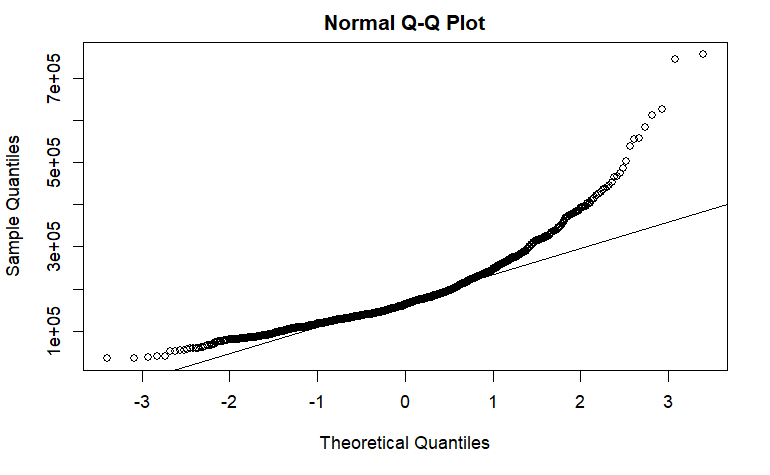

```r
qqnorm(all$SalePrice)
qqline(all$SalePrice)
```

```r
all$SalePrice <- log(all$SalePrice)
skew(all$SalePrice)
```

```
[1] 0.1213182
```

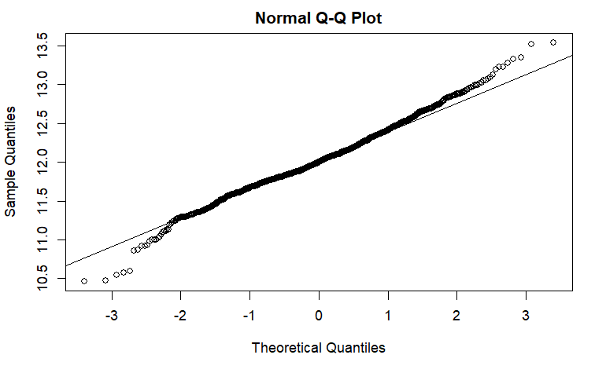

```r
qqnorm(all$SalePrice)
qqline(all$SalePrice)
```

```r
train1 <- combined[!is.na(all$SalePrice),]
test1 <- combined[is.na(all$SalePrice),]
```

# 6. Model

### 6.1 Lasso

```r
my_control <-trainControl(method="cv", number=5)
lassoGrid <- expand.grid(alpha = 1, lambda = seq(0.001,0.1,by = 0.0005))

lasso_mod <- train(x=train1, y=all$SalePrice[!is.na(all$SalePrice)], method='glmnet', trControl= my_control, tuneGrid=lassoGrid)
lasso_mod$bestTune
```

|  | alpha | lambda |
| --- | --- | --- |
| 5 | 1 | 0.003 |

```r
lassoVarImp <- varImp(lasso_mod,scale=F)
lassoImportance <- lassoVarImp$importance
varsSelected <- length(which(lassoImportance$Overall!=0))
varsNotSelected <- length(which(lassoImportance$Overall==0))

cat('Lasso uses', varsSelected, 'variables in its model, and did not select', varsNotSelected, 'variables.')
```

```
Lasso uses 107 variables in its model, and did not select 139 variables.
```

```r
min(lasso_mod$results$RMSE)
```

```
[1] 0.1143996
```

```r
LassoPred <- predict(lasso_mod, test1)
predictions_lasso <- exp(LassoPred)
```

### 6.2 XGBoost model

```r
xgb_grid = expand.grid(
nrounds = 1000,
eta = c(0.1, 0.05, 0.01),
max_depth = c(2, 3, 4, 5, 6),
gamma = 0,
colsample_bytree=1,
min_child_weight=c(1, 2, 3, 4 ,5),
subsample=1
)
```

```r
xgb_caret <- train(x=train1, y=all$SalePrice[!is.na(all$SalePrice)], method='xgbTree', trControl= my_control, tuneGrid=xgb_grid)
xgb_caret$bestTune
```

|  | nrounds | max_depth | eta | gamma | colsample_bytree | min_child_weight | subsample |
| --- | --- | --- | --- | --- | --- | --- | --- |
| 35 | 1000 | 3 | 0.05 | 0 | 1 | 5 | 1 |

```r
label_train <- all$SalePrice[!is.na(all$SalePrice)]

dtrain <- xgb.DMatrix(data = as.matrix(train1), label= label_train)
dtest <- xgb.DMatrix(data = as.matrix(test1))
```

```r
default_param<-list(
        objective = "reg:linear",
        booster = "gbtree",
        eta=0.05,
        gamma=0,
        max_depth=3,
        min_child_weight=5,
        subsample=1,
        colsample_bytree=1
)
```

```r
xgbcv <- xgb.cv( params = default_param, data = dtrain, nrounds = 500, nfold = 5, showsd = T, stratified = T, print_every_n = 40, early_stopping_rounds = 10, maximize = F)
```

[output not shown]

```r
xgb_mod <- xgb.train(data = dtrain, params=default_param, nrounds = 340)
```

```
[11:58:34] WARNING: amalgamation/../src/objective/regression_obj.cu:203: reg:linear is now deprecated in favor of reg:squarederror.
```

```r
XGBpred <- predict(xgb_mod, dtest)
predictions_XGB <- exp(XGBpred) #need to reverse the log to the real values
head(predictions_XGB)
```

```
[1] 116515.2 160781.6 187325.9 188229.9 196022.9 166048.0
```

## 7. Prediction

```r
sub_avg <- data.frame(Id = test_id, SalePrice = (predictions_XGB+2*predictions_lasso)/3)
```

```r
write.csv(sub_avg, file = 'average.csv', row.names = F)
```